# Hitter Development Report

← Team overview · League overview

# Vladimir Guerrero Jr.

**2026 season · Profile: Balanced · xwOBA 0.331 (63rd percentile)**

Vladimir Guerrero Jr. squares up the ball at an above-average rate (63rd percentile) with bat speed in the 93rd percentile. Main lever: **maintain the swing; look for gains in decisions and timing.**

## Swing profile vs MLB

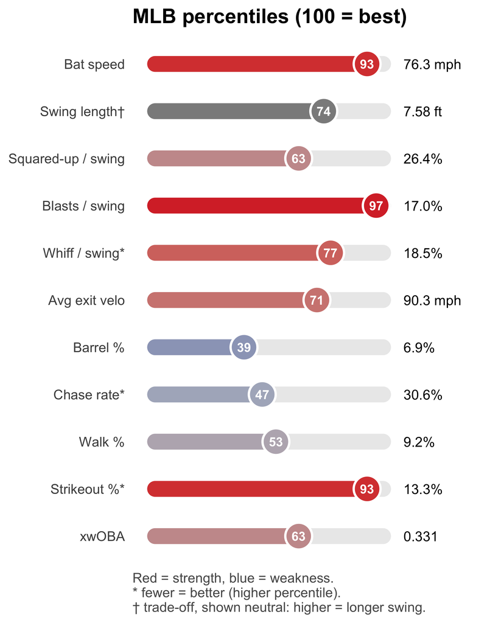

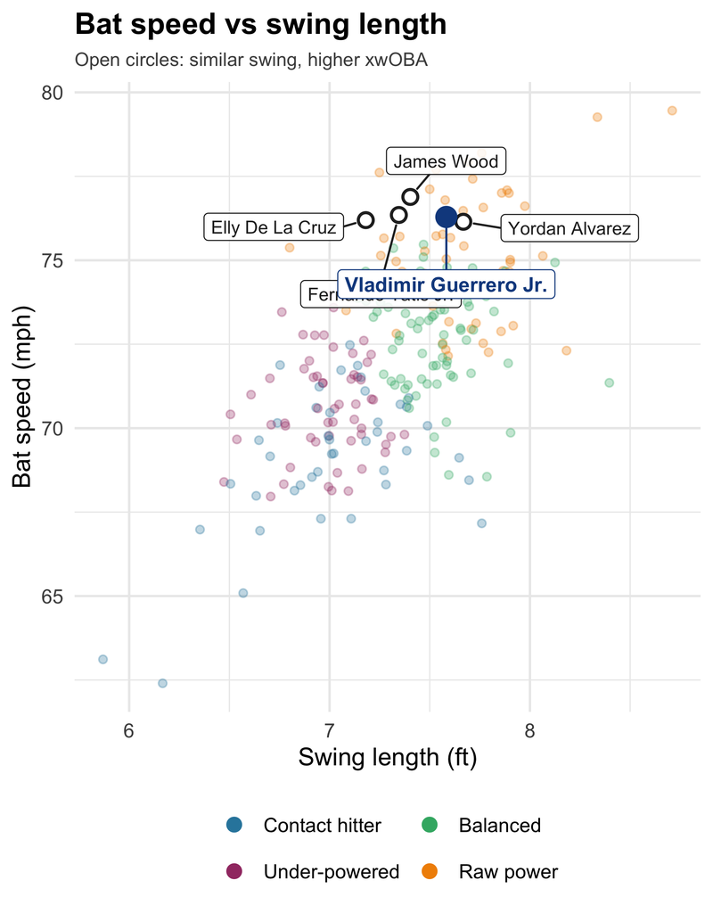

## Year-over-year

| Season | Bat speed (mph) | Swing length (ft) | Squared-up / swing | Whiff / swing | xwOBA | wOBA (actual) |
| --- | --- | --- | --- | --- | --- | --- |
| 2025 | 76.7 | 7.63 | 29.8% | 20.8% | 0.384 | 0.366 |
| 2026 | 76.3 | 7.58 | 26.4% | 18.5% | 0.331 | 0.305 |
| Change | -0.4 | -0.05 | -3.4 pts | -2.2 pts | -0.053 | -0.061 |

**From 2025 to 2026:** bat speed stayed flat, squared-up rate fell 3.4 pts and xwOBA fell 53 points.

Actual wOBA fell short of xwOBA in both seasons (-18, -26 pts): results may understate his contact quality – to verify with spray-chart and batted-ball data.

## What the model says

Across 232 qualified MLB hitters in 2026, at equal swing length, contact and whiff rate, **+1 mph of bat speed is associated with +10 points of xwOBA**, and +1 point of squared-up rate with +4 points. The swing metrics explain 42% of the differences in production between hitters; adding swing decisions (chase and in-zone swing rates) raises it to 47%. The rest comes from timing, launch direction and factors public data does not capture.

These are cross-sectional associations, not guarantees: they set the hypothesis to test with the player, not the expected outcome.

## Development plan

**Diagnosis.** Vladimir Guerrero Jr. combines elite bat speed (93rd percentile) with above-average contact (63rd percentile).

**Priority.** Maintain the swing; marginal gains are more likely in swing decisions and timing than in mechanics.

1. **Monitor** – Track bat speed across the season to catch fatigue-related drops.
2. **Explore** – Chase and in-zone decisions with the hitting coaches.

Reference points – similar swing, higher xwoba

| Comparable hitter | Bat speed (mph) | Squared-up / swing | xwOBA |
| --- | --- | --- | --- |
| Yordan Alvarez | 76.1 | 26.7% | 0.442 |
| James Wood | 76.9 | 25.4% | 0.403 |
| Fernando Tatis Jr. | 76.3 | 28.0% | 0.379 |
| Elly De La Cruz | 76.2 | 25.1% | 0.376 |

Data: Baseball Savant, public Statcast data (bat tracking, expected stats, exit velocity). Bat speed = average of the top 90% of competitive swings. Percentiles (1–100), model and profiles are based on the 232 qualified MLB hitters in 2026 (570+ competitive swings). Profiles: k-means on bat speed, swing length, squared-up and whiff rates. Internal biomechanics data would replace the screening hypotheses with measured values. Report: Hugo Leligny.

Hugo Leligny · Sport Scientist & Performance Analyst  
Measure → Analyze → Decide → Train → Monitor → Adapt ↻  
hugoleligny14@gmail.com · [GitHub](https://github.com/hugollel/blue-jays-hitting)